# lecture11

```python
import numpy as np
import pandas as pd
from sklearn import linear_model
import matplotlib.pyplot as plt
```

```python
df_all = pd.read_csv('BechleLUR_2006_allmodelbuildingdata.csv')
```

```python
for i in df_all.columns:
    print(i,end="\n ")
```

```
Monitor_ID
 State
 Latitude
 Longitude
 Observed_NO2_ppb
 Predicted_NO2_ppb
 WRF+DOMINO
 Distance_to_coast_km
 Elevation_truncated_km
 Impervious_100
 Impervious_200
 Impervious_300
 Impervious_400
 Impervious_500
 Impervious_600
 Impervious_700
 Impervious_800
 Impervious_1000
 Impervious_1200
 Impervious_1500
 Impervious_1800
 Impervious_2000
 Impervious_2500
 Impervious_3000
 Impervious_3500
 Impervious_4000
 Impervious_5000
 Impervious_6000
 Impervious_7000
 Impervious_8000
 Impervious_10000
 Population_100
 Population_200
 Population_300
 Population_400
 Population_500
 Population_600
 Population_700
 Population_800
 Population_1000
```

[output cut: 80 more lines]

```
 total_3500
 total_4000
 total_5000
 total_6000
 total_7000
 total_8000
 total_10000
 total_10500
 total_11000
 total_11500
 total_12000
 total_12500
 total_13000
 total_13500
 total_14000
```

```python
df_all.head()
```

|  | Monitor_ID | State | Latitude | Longitude | Observed_NO2_ppb | Predicted_NO2_ppb | WRF+DOMINO | Distance_to_coast_km | Elevation_truncated_km | Impervious_100 | ... | total_8000 | total_10000 | total_10500 | total_11000 | total_11500 | total_12000 | total_12500 | total_13000 | total_13500 | total_14000 |
| --- | --- | --- | --- | --- | --- | --- | --- | --- | --- | --- | --- | --- | --- | --- | --- | --- | --- | --- | --- | --- | --- |
| 0 | 04-013-0019-42602-1 | AZ | 33.48385 | -112.14257 | 23.884706 | 20.986643 | 11.615223 | 313.0 | 0.304 | 59.4431 | ... | 1788.38015 | 2637.91917 | 2862.73591 | 3096.99468 | 3339.22952 | 3609.20650 | 3896.25748 | 4150.54739 | 4396.96011 | 4651.18890 |
| 1 | 04-013-3002-42602-6 | AZ | 33.45793 | -112.04601 | 25.089886 | 20.990096 | 11.472677 | 323.8 | 0.304 | 72.0000 | ... | 1731.04787 | 2562.32948 | 2791.32295 | 3015.79024 | 3248.95785 | 3489.76919 | 3723.01595 | 3963.41655 | 4196.37496 | 4459.57421 |
| 2 | 04-013-3003-42602-1 | AZ | 33.47968 | -111.91721 | 19.281969 | 18.088153 | 8.990372 | 308.4 | 0.304 | 53.0000 | ... | 1254.14847 | 1965.43346 | 2157.42878 | 2362.96458 | 2584.38952 | 2820.52494 | 3052.44507 | 3315.05126 | 3607.37536 | 3921.12841 |
| 3 | 04-013-3010-42602-1 | AZ | 33.46093 | -112.11748 | 30.645138 | 20.358009 | 11.919268 | 309.0 | 0.304 | 61.3099 | ... | 1599.66889 | 2449.51041 | 2660.60636 | 2879.53599 | 3109.74604 | 3339.37790 | 3597.15279 | 3848.61451 | 4125.08884 | 4427.95530 |
| 4 | 04-013-4011-42602-1 | AZ | 33.37005 | -112.62070 | 11.070412 | 8.549622 | 2.141366 | 269.5 | 0.293 | 12.0000 | ... | 149.29461 | 222.34687 | 244.41106 | 269.54740 | 293.31410 | 320.37722 | 349.76462 | 386.03419 | 412.91888 | 441.52860 |

5 rows × 135 columns

Question: Which variables would be a bad idea to include in the model? That is, before we try to do any model selection, what's obviously out?

Now let's build some models.

First let's try regressing observed NO2 against the satellite measuremenets (you'll do this in HW)

```python
lm = linear_model.LinearRegression(fit_intercept=True)
```

Very important note: scikit-learn wants a data frame for the predictors -- if you have only one predictor and you pass in a pandas series, scikit-learn throws an error.

```python
predictors = df_all.loc[:,['WRF+DOMINO']]
output = df_all['Observed_NO2_ppb']
lm.fit(predictors, output)
```

```
LinearRegression(copy_X=True, fit_intercept=True, n_jobs=1, normalize=False)
```

```python
print('slope is',lm.coef_[0])
print('intercept is',lm.intercept_)
```

```
slope is 0.9454376341994829
intercept is 6.38170588596228
```

```python
y_hat = lm.predict(predictors)
```

```
Text(0,0.5,'Predicted NO2')
```

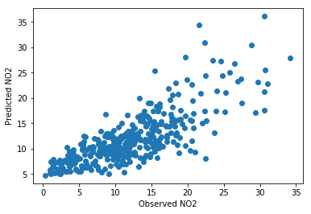

```python
plt.scatter(output,y_hat)
plt.xlabel('Observed NO2')
plt.ylabel('Predicted NO2')
```

```
Text(0,0.5,'Residual')
```

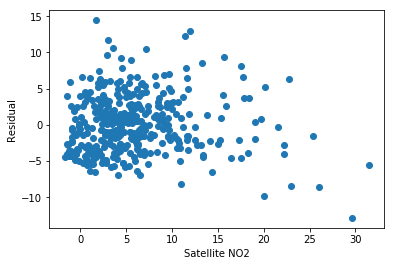

```python
plt.scatter(predictors, output-y_hat)
plt.xlabel('Satellite NO2')
plt.ylabel('Residual')
```

Now let's look at the regression results using a different package called statsmodels

```python
import statsmodels.api as sm
from scipy import stats
```

There is a nice feature in statsmodels that allows you to add a constant to a dataframe:

```python
predictors_const = sm.add_constant(predictors)
predictors_const.head()
```

|  | const | WRF+DOMINO |
| --- | --- | --- |
| 0 | 1.0 | 11.615223 |
| 1 | 1.0 | 11.472677 |
| 2 | 1.0 | 8.990372 |
| 3 | 1.0 | 11.919268 |
| 4 | 1.0 | 2.141366 |

```python
est = sm.OLS(output, predictors_const)
est_fit = est.fit()
print(est_fit.summary())
```

```
                            OLS Regression Results
==============================================================================
Dep. Variable:       Observed_NO2_ppb   R-squared:                       0.621
Model:                            OLS   Adj. R-squared:                  0.620
Method:                 Least Squares   F-statistic:                     601.5
Date:                Thu, 27 Sep 2018   Prob (F-statistic):           2.46e-79
Time:                        09:37:10   Log-Likelihood:                -1038.0
No. Observations:                 369   AIC:                             2080.
Df Residuals:                     367   BIC:                             2088.
Df Model:                           1
Covariance Type:            nonrobust
==============================================================================
                 coef    std err          t      P>|t|      [0.025      0.975]
------------------------------------------------------------------------------
const          6.3817      0.309     20.651      0.000       5.774       6.989
WRF+DOMINO     0.9454      0.039     24.525      0.000       0.870       1.021
==============================================================================
Omnibus:                       16.105   Durbin-Watson:                   1.333
Prob(Omnibus):                  0.000   Jarque-Bera (JB):               17.133
Skew:                           0.481   Prob(JB):                     0.000190
Kurtosis:                       3.434   Cond. No.                         11.9
==============================================================================

Warnings:
[1] Standard Errors assume that the covariance matrix of the errors is correctly specified.
```

Now let's try estimating a model with **all** the predictors embedded:

```python
predictors_all = df_all.loc[:,'WRF+DOMINO':'total_14000']
predictors_all_const = sm.add_constant(predictors_all)
est_all = sm.OLS(output, predictors_all_const)
est_all_fit = est_all.fit()
print(est_all_fit.summary())
```

```
                            OLS Regression Results
==============================================================================
Dep. Variable:       Observed_NO2_ppb   R-squared:                       0.852
Model:                            OLS   Adj. R-squared:                  0.792
Method:                 Least Squares   F-statistic:                     14.09
Date:                Thu, 27 Sep 2018   Prob (F-statistic):           2.40e-66
Time:                        09:37:12   Log-Likelihood:                -863.94
No. Observations:                 369   AIC:                             1944.
Df Residuals:                     261   BIC:                             2366.
Df Model:                         107
Covariance Type:            nonrobust
==========================================================================================
                             coef    std err          t      P>|t|      [0.025      0.975]
------------------------------------------------------------------------------------------
const                      1.9916      0.585      3.406      0.001       0.840       3.143
WRF+DOMINO                 0.8064      0.065     12.429      0.000       0.679       0.934
Distance_to_coast_km      -0.0007      0.000     -1.475      0.141      -0.002       0.000
Elevation_truncated_km     9.9698      1.970      5.060      0.000       6.090      13.850
Impervious_100             0.5512      0.307      1.793      0.074      -0.054       1.157
Impervious_200            -0.7037      0.702     -1.003      0.317      -2.086       0.678
Impervious_300            -0.1042      1.136     -0.092      0.927      -2.340       2.132
Impervious_400             0.9484      1.688      0.562      0.575      -2.375       4.272
Impervious_500            -1.3097      2.616     -0.501      0.617      -6.461       3.841
Impervious_600             0.3312      3.894      0.085      0.932      -7.336       7.998
Impervious_700             0.1111      4.653      0.024      0.981      -9.051       9.273
Impervious_800             1.1207      3.542      0.316      0.752      -5.854       8.096
Impervious_1000           -2.5260      2.186     -1.156      0.249      -6.829       1.777
Impervious_1200            2.7491      1.946      1.413      0.159      -1.083       6.581
Impervious_1500           -2.5340      1.789     -1.416      0.158      -6.057       0.989
Impervious_1800            3.1168      2.586      1.205      0.229      -1.976       8.209
Impervious_2000           -1.8973      2.308     -0.822      0.412      -6.442       2.647
Impervious_2500           -0.3520      1.413     -0.249      0.803      -3.134       2.430
Impervious_3000            2.5705      1.785      1.440      0.151      -0.944       6.085
Impervious_3500           -3.6613      2.244     -1.632      0.104      -8.080       0.757
Impervious_4000            2.6792      1.815      1.476      0.141      -0.895       6.253
Impervious_5000           -1.5423      1.277     -1.208      0.228      -4.056       0.972
Impervious_6000            0.3043      1.560      0.195      0.846      -2.768       3.377
Impervious_7000            0.8075      1.905      0.424      0.672      -2.943       4.558
Impervious_8000           -0.6534      1.455     -0.449      0.654      -3.519       2.212
Impervious_10000           0.0796      0.472      0.169      0.866      -0.850       1.009
```

[output cut: 100 more lines]

```
total_12500               -0.1364      0.073     -1.862      0.064      -0.281       0.008
total_13000                0.0923      0.071      1.293      0.197      -0.048       0.233
total_13500               -0.0294      0.073     -0.401      0.688      -0.173       0.115
total_14000                0.0004      0.036      0.010      0.992      -0.071       0.072
==============================================================================
Omnibus:                       24.452   Durbin-Watson:                   1.677
Prob(Omnibus):                  0.000   Jarque-Bera (JB):               28.722
Skew:                           0.582   Prob(JB):                     5.80e-07
Kurtosis:                       3.717   Cond. No.                     1.39e+16
==============================================================================

Warnings:
[1] Standard Errors assume that the covariance matrix of the errors is correctly specified.
[2] The smallest eigenvalue is 3.73e-22. This might indicate that there are
strong multicollinearity problems or that the design matrix is singular.
```

Now let's look at what happens if we drop some of the predictors

```python
predictors_less = df_all.loc[:,'WRF+DOMINO':'Resident_100']
predictors_less_const = sm.add_constant(predictors_less)
est_less = sm.OLS(output, predictors_less_const)
est_less_fit = est_less.fit()
print(est_less_fit.summary())
```

```
                            OLS Regression Results
==============================================================================
Dep. Variable:       Observed_NO2_ppb   R-squared:                       0.829
Model:                            OLS   Adj. R-squared:                  0.789
Method:                 Least Squares   F-statistic:                     20.67
Date:                Thu, 27 Sep 2018   Prob (F-statistic):           8.36e-81
Time:                        09:37:13   Log-Likelihood:                -890.94
No. Observations:                 369   AIC:                             1924.
Df Residuals:                     298   BIC:                             2202.
Df Model:                          70
Covariance Type:            nonrobust
==========================================================================================
                             coef    std err          t      P>|t|      [0.025      0.975]
------------------------------------------------------------------------------------------
const                      2.0213      0.456      4.432      0.000       1.124       2.919
WRF+DOMINO                 0.7287      0.057     12.724      0.000       0.616       0.841
Distance_to_coast_km      -0.0009      0.000     -2.162      0.031      -0.002   -8.15e-05
Elevation_truncated_km    10.5693      1.859      5.686      0.000       6.911      14.228
Impervious_100             0.5015      0.276      1.815      0.071      -0.042       1.045
Impervious_200            -0.6505      0.635     -1.025      0.306      -1.900       0.599
Impervious_300            -0.3161      1.068     -0.296      0.767      -2.417       1.785
Impervious_400             1.7851      1.620      1.102      0.271      -1.403       4.974
Impervious_500            -3.8673      2.475     -1.563      0.119      -8.737       1.003
Impervious_600             4.8727      3.595      1.355      0.176      -2.202      11.948
Impervious_700            -4.3304      4.283     -1.011      0.313     -12.758       4.098
Impervious_800             3.4336      3.241      1.060      0.290      -2.944       9.811
Impervious_1000           -3.2495      2.004     -1.621      0.106      -7.194       0.695
Impervious_1200            3.0688      1.770      1.734      0.084      -0.415       6.553
Impervious_1500           -2.5027      1.646     -1.520      0.130      -5.743       0.737
Impervious_1800            2.6706      2.427      1.100      0.272      -2.106       7.447
Impervious_2000           -1.3275      2.169     -0.612      0.541      -5.596       2.941
Impervious_2500           -0.8193      1.320     -0.621      0.535      -3.417       1.779
Impervious_3000            2.4335      1.665      1.462      0.145      -0.843       5.710
Impervious_3500           -3.1548      2.110     -1.495      0.136      -7.307       0.997
Impervious_4000            2.1392      1.701      1.258      0.209      -1.208       5.486
Impervious_5000           -1.1924      1.176     -1.014      0.311      -3.507       1.122
Impervious_6000            1.4207      1.429      0.994      0.321      -1.392       4.234
Impervious_7000           -1.1405      1.670     -0.683      0.495      -4.426       2.145
Impervious_8000            0.3382      1.158      0.292      0.771      -1.942       2.618
Impervious_10000          -0.0632      0.327     -0.193      0.847      -0.707       0.581
```

[output cut: 41 more lines]

```
Major_7000                 0.0903      0.036      2.493      0.013       0.019       0.162
Major_8000                -0.0591      0.027     -2.226      0.027      -0.111      -0.007
Major_10000                0.0069      0.010      0.705      0.482      -0.012       0.026
Resident_100               3.4245      1.164      2.943      0.004       1.134       5.715
==============================================================================
Omnibus:                       18.950   Durbin-Watson:                   1.493
Prob(Omnibus):                  0.000   Jarque-Bera (JB):               22.048
Skew:                           0.481   Prob(JB):                     1.63e-05
Kurtosis:                       3.714   Cond. No.                     4.91e+05
==============================================================================

Warnings:
[1] Standard Errors assume that the covariance matrix of the errors is correctly specified.
[2] The condition number is large, 4.91e+05. This might indicate that there are
strong multicollinearity or other numerical problems.
```

Some things to note:

1. AIC is lower for *_less. *_all does a better job of reducing squared error, but it gets penalized more for having more variables.
2. Look at the p-values and confidence intervals. You can see that p-values are big (>0.05) when confidence intervals span zero.
3. Resident*100 was insignificant when included with lots of other Resident** variables, but on it's own it is strongly significant.